# 01e. Complete single-end ITS2 preprocessing

Cutadapt forward / QC20 / maxEE 2 — ITSxpress 적용 전 QC

2026-10-16

# 1 1. 분석 범위

이번 보고서는 새로 완료된 **Cutadapt forward single-end** 결과만 사용하여 다음을 수행한다.

1. QIIME2 DADA2 table, representative sequence 및 UNITE taxonomy 무결성 확인
2. metadata 연결 및 sample 일치 검증
3. fungal phyloseq 생성과 단계별 sample/ASV/read audit
4. DADA2 filtering 및 chimera 제거 retention 확인
5. read depth, observed ASV, ASV 길이 및 taxonomy resolution 확인
6. 기존 시험용 Cutadapt Single 결과와 exact-ASV 수준 비교
7. Aureobasidium-like signal의 회수 여부 확인

ITSxpress 결과는 아직 생성되지 않았으므로 본 보고서에는 Cutadapt–ITSxpress 비교를 넣지 않았다. Rarefaction, abundance filtering, decontam 및 True–Control 가설검정도 적용하지 않았다.

## 1.1 실행 조건

[output not shown]

이번 결과의 `maxEE`는 single-end이므로 **2**이다. 기존 파일명에 사용된 `ee22`는 paired workflow의 표기이고, 본 phyloseq 출력명에는 혼동을 피하기 위해 `ee2`를 사용한다.

# 2 2. QIIME2 결과 import와 무결성 확인

| Item | Value |
| --- | --- |
| Pipeline completion | 2026-10-16 17:34:57.888020 |
| Samples requested | 83 |
| Samples retained | 83 |
| DADA2 samples | 83 |
| Raw ASVs | 1855 |
| Raw table reads | 1186913 |
| Repseq ASVs | 1855 |
| Taxonomy rows | 1855 |

# 3 3. Metadata 연결과 phyloseq 생성

| Check | N |
| --- | --- |
| New table samples | 83 |
| Metadata samples | 83 |
| Shared samples | 83 |
| New-table only | 0 |
| Metadata only | 0 |

| Stage | Samples | ASVs | Total_Reads |
| --- | --- | --- | --- |
| Imported ASV table | 83 | 1855 | 1186913 |
| Kingdom == Fungi retained | 83 | 1855 | 1186913 |
| Zero-sum samples/taxa removed | 83 | 1855 | 1186913 |

# 4 4. DADA2 read retention

| Stage | Reads | Percent_of_input |
| --- | --- | --- |
| Input | 1337703 | 100 |
| Filtered | 1251843 | 93.5815349147008 |
| Denoised | 1225899 | 91.64209095740983 |
| Non-chimeric | 1186913 | 88.72769217083314 |

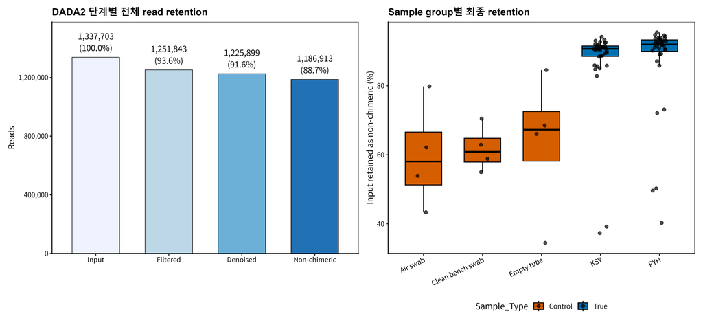

# 5 5. 최종 library depth와 observed ASV

| Sample_Type | Display_Group | N | Min_Reads | Median_Reads | Max_Reads | Median_Observed_ASV |
| --- | --- | --- | --- | --- | --- | --- |
| Control | Air swab | 4 | 1712 | 2410 | 6707 | 25.5 |
| Control | Clean bench swab | 4 | 1838 | 2655.5 | 3856 | 17.5 |
| Control | Empty tube | 4 | 2333 | 3754 | 7312 | 25.5 |
| True | KSY | 35 | 1226 | 11943 | 18909 | 56 |
| True | PYH | 36 | 1866 | 22034.5 | 44819 | 79.5 |

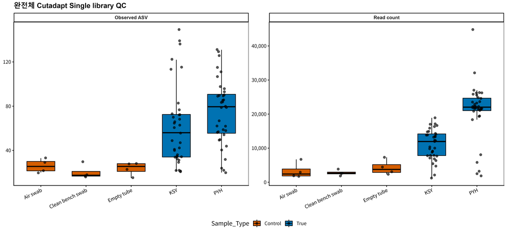

# 6 6. ASV 길이와 taxonomy resolution

| ASVs | Min | Q1 | Median | Q3 | Max | ASV_length_le_100 | Reads_length_le_100 |
| --- | --- | --- | --- | --- | --- | --- | --- |
| 1855 | 50 | 271 | 281 | 281 | 282 | 297 | 38782 |

| Rank | Classified_ASVs | Total_ASVs | Classified_Percent |
| --- | --- | --- | --- |
| Kingdom | 1855 | 1855 | 100 |
| Phylum | 1349 | 1855 | 72.722371967655 |
| Class | 1215 | 1855 | 65.49865229110512 |
| Order | 1186 | 1855 | 63.93530997304583 |
| Family | 1146 | 1855 | 61.77897574123989 |
| Genus | 1096 | 1855 | 59.08355795148248 |
| Species | 934 | 1855 | 50.35040431266847 |

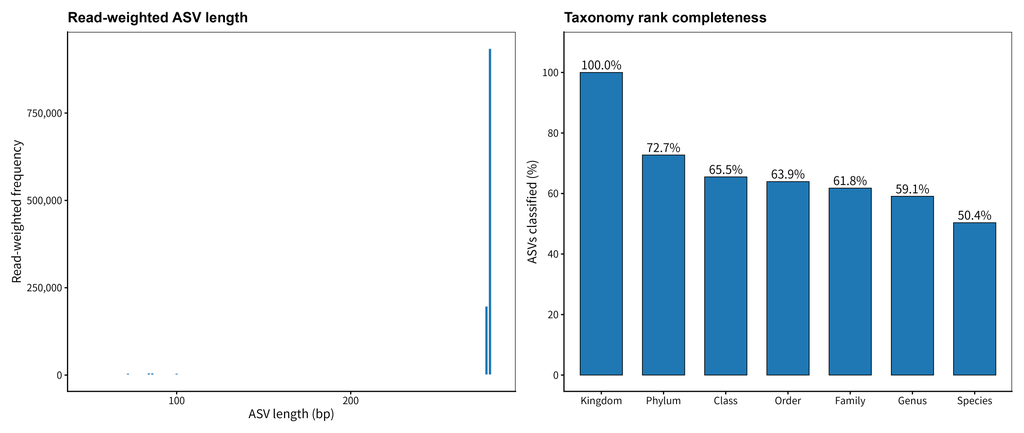

# 7 7. 기존 시험용 Cutadapt Single과 비교

| Metric | Previous | Complete |
| --- | --- | --- |
| Samples | 83 | 83 |
| Final fungal ASVs | 1860 | 1855 |
| Total fungal reads | 1169781 | 1186913 |
| Exact shared ASVs | 1379 | 1379 |
| Complete-only ASVs |  | 476 |
| Previous-only ASVs | 481 |  |
| Complete reads in shared ASVs (%) |  | 95.62781770862733 |
| Previous reads in shared ASVs (%) | 96.69279976337451 |  |
| Sample-depth Spearman rho | 0.9907854414172367 | 0.9907854414172367 |

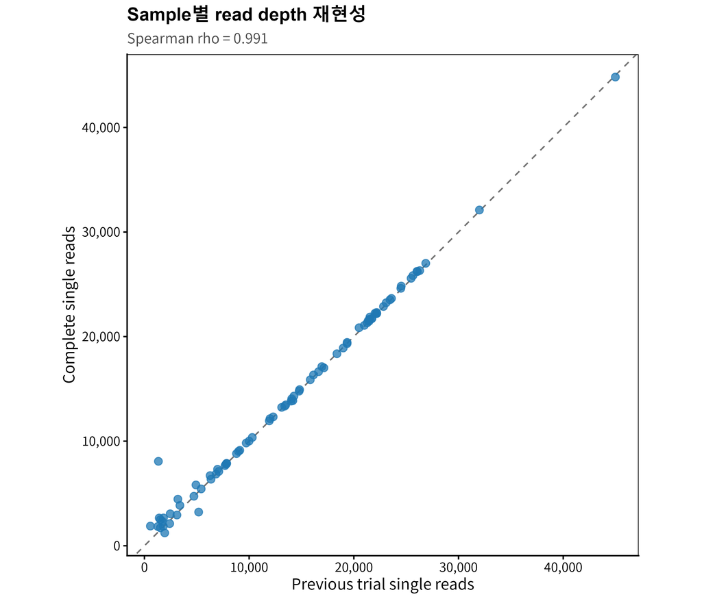

새 결과는 기존 시험용 결과와 별도의 산출물이므로 exact ASV와 read 변화가 존재한다. 이후 분석은 본 보고서에서 저장한 완전체 phyloseq를 기준으로 고정한다.

# 8 8. Aureobasidium-like signal 확인

| FeatureID | Length_bp | Total_Reads | Prevalence | Read_Fraction_Percent | Genus | Species |
| --- | --- | --- | --- | --- | --- | --- |
| 10e25f6b435d5136e1565c0b20a20cfc | 281 | 400005 | 78 | 33.70129065904577 | Aureobasidium | Aureobasidium_tremulum |
| b4f38aaf269ff08535fc440b5e8e52f8 | 281 | 26711 | 29 | 2.250459806236851 | Aureobasidium |  |
| 3bfa92476cc05fd6c57650c07c88cf10 | 281 | 520 | 2 | 0.04381113021763179 | Aureobasidium |  |
| f4afe240949d086bdb5a35eae85889a4 | 281 | 501 | 6 | 0.04221033892121832 | Aureobasidium | Aureobasidium_pullulans |
| 74691e17a7abbf42e25cbac604e92b85 | 281 | 204 | 4 | 0.01718744339307093 | Aureobasidium | Aureobasidium_pullulans |
| 1841176cb9159f5802e0decea4e44d3f | 281 | 180 | 5 | 0.01516539122918023 | Aureobasidium | Aureobasidium_pullulans |
| 0308b938862a60c3caa5a996c5d10417 | 281 | 46 | 1 | 0.003875599980790504 | Aureobasidium |  |
| 5fff8f302e81cc444cfdfacb119d28d3 | 281 | 27 | 2 | 0.002274808684377035 | Aureobasidium | Aureobasidium_pullulans |
| 37dcb6297448140a1e9e966a72f82cc2 | 281 | 26 | 1 | 0.002190556510881589 | Aureobasidium | Aureobasidium_tremulum |
| a8714773729d340797d55755eb37a3ea | 281 | 25 | 1 | 0.002106304337386144 | Aureobasidium | Aureobasidium_pullulans |

대표 ASV의 UNITE species label은 classifier 결과이다. 기존 BLAST에서는 303-bp full sequence와 155-bp core가 `A. pullulans` 및 `A. melanogenum`에 동일하게 100% query cover/identity를 보여, species 고유성은 확인되지 않았다. 따라서 현 단계에서도 `Aureobasidium-like ASV`로 보수적으로 해석한다.

# 9 9. 결론

- 입력 83개 sample은 모두 DADA2 결과와 metadata에 연결되었다.
- DADA2 input 1,337,703 reads 중 1,186,913 reads(88.7%)가 non-chimeric으로 유지되었다.
- 최종 fungal phyloseq에는 83개 library, 1855개 ASV, 1,186,913 reads가 포함되었다.
- 완전체 Cutadapt Single phyloseq를 `Phyloseq/phy_ITS2_cutadapt_single_complete_q20_ee2_20261016.rds`에 저장하였다.
- ITSxpress Single이 완료되면 동일 sample과 sequence-family 기준으로 본 객체와 비교한다.

# 10 10. 제한점과 다음 단계

- 본 보고서는 Cutadapt forward single-end 결과의 preprocessing QC이며 biological hypothesis test가 아니다.
- abundance threshold와 singleton removal은 적용하지 않았다. 향후 제거 기준은 depth와 ASV frequency를 검토한 뒤 사용자가 결정해야 한다.
- rarefaction은 수행하지 않았으며 taxa filtering에도 사용하지 않았다.
- decontam은 수행하지 않았다. Control source와 DNA concentration을 포함한 method/threshold 결정이 선행되어야 한다.
- ITSxpress Single 결과가 아직 없으므로 현재 단계에서 Cutadapt와 ITSxpress 중 최종 방법을 확정하지 않는다.
- Aureobasidium species label은 BLAST상 비고유적이므로 species 수준 확정으로 사용하지 않는다.

ITSxpress Single 완료 후 다음 비교만 추가하면 된다.

1. sample별 read retention 및 observed ASV
2. exact containment 기반 sequence-family 대응
3. taxonomy rank 변화와 BLAST-supported focal ASV
4. Aitchison PCoA와 sample별 composition 일치도
5. Aureobasidium-like family 회수 여부